# Introductory Text-An with Tidytext

Sudhir Voleti

### Basic Intro to Tidytext

Tidytext is text-an part of ‘tidyverse’ - a set of popular packages that work on a common set of code principles called the [‘tidy data framework’](https://cran.r-project.org/web/packages/tidyr/vignettes/tidy-data.html) originally created by the legendary (in R circles, at least) Hadley Wickham.

We’ll see some of these tidy data handling procedures as we proceed ahead. Tidytext (Silge and Robinson 2016) is described thus by its creators:

> “Treating text as data frames of individual words allows us to manipulate, summarize, and visualize the characteristics of text easily and integrate natural language processing into effective workflows we were already using.”

So let’s jump right in.

```r
if (!require(tidyverse)) {install.packages("tidyverse")}
if (!require(tidytext)) {install.packages("tidytext")}
library(tidyverse)
library(tidytext)
library(ggplot2)
```

### Tidytext Analysis on the Nokia dataset

I return to an old favorite here: the 2013 Amazon Nokia Lumia reviews dataset of 120 consumer reviews.

One advantage is that I can read the data directly off my github page.

```r
# Example reading in an amazon nokia corpus
nokia = readLines('https://github.com/sudhir-voleti/sample-data-sets/raw/master/text%20analysis%20data/amazon%20nokia%20lumia%20reviews.txt')
# a0 = readLines(file.choose())    # alternately, do this to read file from local machine
text <- nokia
text  =  gsub("<.*?>", " ", text)              # regex for removing HTML tags
length(text)    # 120 documents
```

```
[1] 120
```

### Tidytext Tokenization with unnest_tokens()

First thing to note before invoking tidytext - get the text into a `data_frame` format, called a `tibble`, which has nice printing properties - e.g., it never floods the console.

In other words, we convert text_df into one-token-per-document-per-row.

Now time to see tidytext’s neat tokenizing capabilities at the level of:

- 1. words,
- 2. sentences,
- 3. paragraphs, and
- 4. ngrams,

using the `unnest_tokens()` function.

```r
require(tibble)
textdf = tibble(text = text) # yields 120x1 tibble. i.e., each doc = 1 row here.
  # textdf # commenting this out as it is messing up page formatting
# Tokenizing ops. Words first.
system.time({
textdf %>% unnest_tokens(word, text)   # try ?unnest_tokens
})
```

```
   user  system elapsed
   0.01    0.00    0.02
```

Below, we can see sentence tokenization using the `token = "sentences"` parm in `unnest_tokens`.

```r
# Tokenizing into sentences.
system.time({
sent_tokenized = textdf %>% unnest_tokens(sentence, text, token = "sentences") # 868 rows/120 docs ~  8 sentences per doc?
  })   # 0 secs
```

```
   user  system elapsed
   0.01    0.00    0.02
```

```r
# explore output object a bit
class(sent_tokenized)
```

```
[1] "tbl_df"     "tbl"        "data.frame"
```

```r
dim(sent_tokenized)
```

```
[1] 868   1
```

```r
head(sent_tokenized)
```

| sentence |
| --- |
| i have had samsung phones, where the screens are nice, but the plastic bodies come apart all of the time and feel flimsy. |
| i have had iphones, where the user interface is just so boring, even with all those apps that cost you money. |
| the nokia has wonderful nokia apps already installed, such as nokia drive, which gives you directions while you are driving with a talking attendant, it is super accurate and fun to use. |
| you get nokia music, which is a free music service with 1500 playlists put together by expert music people, very good and it's free! |
| you get espn, nokia city lens, which is where you hold your camera up while you are walking a city street and it will give you information about the area and what you are pointing at, it is really coo… |
| and there are other free nokia apps as well, like camera extras, that let you do things like take action shots and panorama photos. |

Sentence detection appears to be good, above. Tokenizing df into bigrams, below. Try different ngrams & see.

```r
system.time({
ngram_tokenized = textdf %>% unnest_tokens(ngram, text, token = "ngrams", n = 2)     # yields (#tokens -1 ) bigrams
})  # 0.03 secs
```

```
   user  system elapsed
   0.04    0.00    0.03
```

```r
#explore the output object
class(ngram_tokenized)
```

```
[1] "tbl_df"     "tbl"        "data.frame"
```

```r
dim(ngram_tokenized)
```

```
[1] 15394     1
```

```r
head(ngram_tokenized)
```

| ngram |
| --- |
| i have |
| have had |
| had samsung |
| samsung phones |
| phones where |
| where the |

### Grouping, Aggegation and Join ops in tidytext

Intuitively, the funcs we’ll call in tidytext are named `group_by()`, `count()` and `join()`. Behold.

```r
# use count() to see most common words
system.time({
nokia_words = textdf %>%
        unnest_tokens(word, text) %>%  # tokenized words in df in 'word' colm
        count(word, sort = TRUE) %>%   # counts & sorts no. of occurrences of each item in 'word' column
        rename(count = n)      # renames the count column from 'n' (default name) to 'count'.
  }) # 0.11 secs
```

```
   user  system elapsed
   0.04    0.00    0.05
```

```r
nokia_words %>% head(., 10) # view top 10 rows in nokia-words df
```

| word | count |
| --- | --- |
| the | 682 |
| i | 510 |
| and | 448 |
| to | 427 |
| phone | 388 |
| a | 362 |
| it | 358 |
| is | 299 |
| for | 202 |
| this | 201 |

Unsurprisingly, the most common words, with the highest no. of occurrences are th scaffolding of grammer - articles, prepositions, conjunctions etc. Not exactly the meaty stuff.

Is there anything we can do about it? Yes, we can. (Pun intended). We could *filter* the words using a *stopwords* list from earlier.

Conveniently, tidytext comes with its own `stop_words` list.

```r
data(stop_words)
# use anti_join() to de-merge stopwords from the df
system.time({
  nokia_new = textdf %>%
        unnest_tokens(word, text) %>%
        count(word, sort = TRUE) %>%
        rename(count = n) %>%
        anti_join(stop_words)   # try ?anti_join
  })  # 0.03 secs
```

```
   user  system elapsed
   0.05    0.00    0.07
```

```r
  nokia_new %>% head(., 10)
```

| word | count |
| --- | --- |
| phone | 388 |
| nokia | 87 |
| windows | 77 |
| apps | 70 |
| lumia | 62 |
| 900 | 45 |
| unlocked | 45 |
| phones | 42 |
| battery | 34 |
| android | 32 |

Aha. With the stopwords filtered out, the scene changes quite a bit.

How about some visualization via bar-charts, just for completeness? See below.

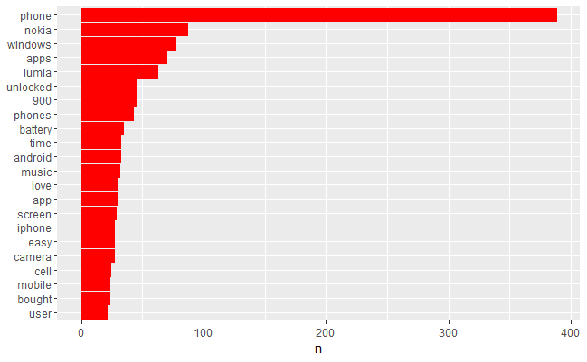

```r
# First, build a datafame
tidy_nokia <- textdf %>%
  unnest_tokens(word, text) %>%     # word tokenization
  anti_join(stop_words)    # run ?join::dplyr
# Visualize the commonly used words using ggplot2.
library(ggplot2)
tidy_nokia %>%
  count(word, sort = TRUE) %>%
  filter(n > 20) %>%   # n is wordcount colname.

  mutate(word = reorder(word, n)) %>%  # mutate() reorders columns & renames too

  ggplot(aes(word, n)) +
  geom_bar(stat = "identity", col = "red", fill = "red") +
  xlab(NULL) +
  coord_flip()
```

### More Bigram ops with tidytext

Bigrams in particular, and ngrams in general will have several uses down the line, as we’ll see. As such they link BOW with NLP in a way.

First, let’s build and view the bigrams with `token = "ngrams, n=2` argument in the `unnest_tokens()` func.

```r
nokia_bigrams <- textdf %>%
  unnest_tokens(bigram, text,
                token = "ngrams", n = 2)
nokia_bigrams
```

| bigram |
| --- |
| i have |
| have had |
| had samsung |
| samsung phones |
| phones where |
| where the |
| the screens |
| screens are |
| are nice |
| nice but |

[output cut: 990 more lines]

Now use `separate()` to str_split() the words.

```r
require(tidyr)
# separate bigrams
bigrams_separated <- nokia_bigrams %>%
                        separate(bigram, c("word1", "word2"), sep = " ")
bigrams_separated
```

| word1 | word2 |
| --- | --- |
| i | have |
| have | had |
| had | samsung |
| samsung | phones |
| phones | where |
| where | the |
| the | screens |
| screens | are |
| are | nice |
| nice | but |

[output cut: 990 more lines]

Very many stopwords in there obscuring meaning. So let’s remove them by successively doing `filter()` on the first and second words.

```r
# filtering the bigrams to remove stopwords
bigrams_filtered <- bigrams_separated %>%
                      filter(!word1 %in% stop_words$word) %>%
                      filter(!word2 %in% stop_words$word)
bigrams_filtered
```

| word1 | word2 |
| --- | --- |
| samsung | phones |
| plastic | bodies |
| feel | flimsy |
| user | interface |
| wonderful | nokia |
| nokia | apps |
| nokia | drive |
| talking | attendant |
| super | accurate |
| nokia | music |

[output cut: 990 more lines]

Other ops like counting and sorting should be standard by now.

```r
# New bigram counts:
bigram_counts <- bigrams_filtered %>%
        count(word1, word2, sort = TRUE)
bigram_counts
```

| word1 | word2 | n |
| --- | --- | --- |
| lumia | 900 | 34 |
| windows | phone | 31 |
| nokia | lumia | 23 |
| battery | life | 14 |
| cell | phone | 12 |
| lumia | 920 | 12 |
| sim | card | 12 |
| windows | 8 | 11 |
| data | plan | 7 |
| gorilla | glass | 7 |

[output cut: 990 more lines]

tidyr’s `unite()` function is the inverse of separate(), and lets us recombine the columns into one.

Thus, “separate / filter / count / unite” functions let us find the most common bigrams not containing stop-words.

```r
bigrams_united <- bigrams_filtered %>%
  unite(bigram, word1, word2, sep = " ")
bigrams_united
```

| bigram |
| --- |
| samsung phones |
| plastic bodies |
| feel flimsy |
| user interface |
| wonderful nokia |
| nokia apps |
| nokia drive |
| talking attendant |
| super accurate |
| nokia music |

[output cut: 990 more lines]

Suppose we want to identify all those bigrams wherein the words “cloud”, “windows” or “solution” appeared either in word1 or in word2.

In other words, we want to match arbitrary word strings with bigram components. See code below.

```r
# filter for bigrams which contain the word game, intelligent, or cloud
arbit_filter = bigrams_filtered %>%
            filter(word1 %in% c("windows", "solution", "cloud") | word2 %in% c("windows", "solution", "cloud")) %>%
      count(word1, word2, sort = TRUE)
arbit_filter %>% filter(word1 == "windows" | word2 == "cloud")   # try for cloud in word2 etc.
```

| word1 | word2 | n |
| --- | --- | --- |
| windows | phone | 31 |
| windows | 8 | 11 |
| windows | phones | 7 |
| windows | 7.5 | 3 |
| windows | platform | 3 |
| windows | 7 | 2 |
| windows | 7.8 | 2 |
| windows | live | 2 |
| free | cloud | 1 |
| frees | cloud | 1 |

[output cut: 12 more lines]

### Casting tidy data into DTMs

Nice that tidy data can do so much. But how about building standard text-an data objects like DTMs etc?

Sure, tidytext can very well do that. First, we convert the text corpus into the tidy format, essentially, one-token-per-row-per-document. See the code below.

```r
# First convert Nokia corpus to tidy format, i.e. a tibble with token and count per row per document.
tidy_nokia = textdf %>%
                    mutate(doc = row_number()) %>%
                    unnest_tokens(word, text) %>%
                    anti_join(stop_words) %>%
                    group_by(doc) %>%
                    count(word, sort=TRUE)
tidy_nokia
```

| doc | word | n |
| --- | --- | --- |
| 25 | phone | 27 |
| 59 | lumia | 20 |
| 2 | phone | 15 |
| 19 | phone | 12 |
| 8 | phone | 11 |
| 25 | sms | 11 |
| 25 | view | 11 |
| 59 | 920 | 11 |
| 59 | windows | 11 |
| 25 | option | 10 |

[output cut: 990 more lines]

Now, to cast this tidy object into a DTM, into a regular (if sparse) matrix etc. See code below.

```r
# cast into a Document-Term Matrix
nokia_dtm = tidy_nokia %>%
            cast_dtm(doc, word, n)
nokia_dtm   # yields a sparse matrix format by default
```

```
<<DocumentTermMatrix (documents: 120, terms: 1964)>>
Non-/sparse entries: 4196/231484
Sparsity           : 98%
Maximal term length: 17
Weighting          : term frequency (tf)
```

Below, we convert `tidy_nokia` into a regular matrix.

```r
# cast into a Matrix object
nokia_dtm <- tidy_nokia %>% cast_sparse(doc, word, n)
    # class(nokia_dtm)  # Matrix
nokia_dtm[1:6,1:6]
```

```
6 x 6 sparse Matrix of class "dgCMatrix"
   phone lumia sms view 920 windows
25    27     7  11   11   .       1
59     9    20   .    .  11      11
2     15     2   .    .   .       4
19    12     1   .    .   .       5
8     11     2   .    .   .       2
9      9     .   .    .   .       .
```

### the TFIDF transformation

Recall we mentioned there’re two weighing schemes for token frequencies in the DTM.

What we saw above was the simpler, first one, namely, term frequency or TF.

Now we introduce the second one - TFIDF. Which stands for term frequency-inverse document frequency.

Time to move to the slides and the board before returning here. Tidytext code for the TFIDF transformation is below.

```r
 nokia_dtm_idf = tidy_nokia %>%
        group_by(doc) %>%
        count(word, sort=TRUE) %>% ungroup() %>%
        bind_tf_idf(word, doc, nn) %>%
        cast_sparse(doc, word, tf_idf)
 nokia_dtm_idf[1:8, 1:8]   # view a few rows
```

```
8 x 8 sparse Matrix of class "dgCMatrix"
       1080p       1500        7.5       720p        7gb   accurate
1 0.03198707 0.03740228 0.02482855 0.03740228 0.03198707 0.03740228
2 .          .          .          .          0.03411954 .
3 .          .          .          .          .          .
4 .          .          .          .          .          .
5 .          .          .          .          .          .
6 .          .          .          .          .          .
7 .          .          .          .          .          .
8 .          .          .          .          .          .
      action     adjust
1 0.03740228 0.03198707
2 .          .
3 .          .
4 .          .
5 .          .
6 .          .
7 .          .
8 .          .
```

Last but not least is the ability to explicitly leverage tidytext’s tidy data format to do some cool stuff. Below is only if we have time.

### Applying Tidy Principles on Text data

The Nokia corpus has 120 documents. Each document has several sentences. And each sentence has several words in it. Here’s a Q for you now.

> Suppose you want to know how many sentences are there in each document in the corpus. And how many words are there in each sentence. How would you go about this?

`dplyr` functions inside tidytext get us there easily because the data are arranged as per tidy principles.

I present a few simple examples below. These operators while simple enable us to build fairly complex structures by recombining and chaining them together.

Let’s answer the question set above. I’ll use functions `row_number()` and `group_by()`. See the code below.

```r
### Create a document id and group_by it
textdf_doc = textdf %>%
              mutate(doc = row_number()) %>%   # creates an id number for each row, i.e., doc.
              select(doc, text)
              # group_by(doc)   # internally groups docs together
textdf_doc
```

| doc | text |
| --- | --- |
| 1 | I have had Samsung phones, where the screens are nice, but the plastic bodies come apart all of the time and feel flimsy. I have had iPhones, where the user interface is just so boring, even with all … |
| 2 | This phone is great! It's the best phone I've ever owned. I have been a dedicated high end Android user, but I found this phone to be a much more satisfying experience than either the iPhone or the An… |
| 3 | I just bought this phone a few weeks ago and it is gorgeous. The screen just blew me away and the OS is very fast and user friendly. This is the first time I try a Windows phone and I have to say that… |
| 4 | Hi, I bought a cell phone by Amazon with the following description: "Nokia 900 Lumia Blue (Cyan) Factory Unlocked", Sold by: BLUTEKUSA. When I got the phone I was surprised that box and cell phone wer… |
| 5 | The Nokia Lumia 900 was my first smartphone. Im a programmer, so I really appreciate how easy it is to write software for it. That being said, the phoen itself is what I'm rating so lets get to it. Th… |
| 6 | I am a tmobile customer and with an unlocked Nokia 900 Lumia from ATT .Let me simply say it has to be one of the best kept secrets in smartphones. Though I knew the phone was unlocked, I had no clue i… |
| 7 | I bought this phone because I wanted to use it on TMobile. I've only been frustrated thus far. Because it was originally an AT&T phone, the picture messaging is all screwed up. I actually regret not w… |
| 8 | I received my phone before the expected arrival date and in excellent condition - New, and the color cyan blue is beautiful. The phone is simply great. It is easy to use, with lots of features, and we… |
| 9 | I bought the phone and it was nice but has one problem that my husband did not like. It did turned off and didn't wanna turn on when somebody was calling. So I ruterned the phone. I did ask the seller… |
| 10 | I purchased the Nokia Lumina 900 in black from BLUTECUSA and was really thrilled with all the new WP features. I really loved the new interface and its one smooth operator. The only issue I had was th… |

[output cut: 110 more lines]

So I have doc id and corresponding text. What I next need is a sentence identifier within each doc.

Then, a word identifier for each word within each sentence. Finally, can simply merge the dataframes. See below.

```r
### How many sentences in each doc?
textdf_sent = textdf_doc %>%
              unnest_tokens(sentence, text, token = "sentences") %>%

              group_by(doc) %>%
              mutate(sent_id = row_number()) %>%      # create sentence id by enumeration
              summarise(sent_doc = max(sent_id)) %>%  # max sent_id is the num of sents in doc

              select(doc, sent_doc)    # retain colms in order for clean display
textdf_sent   # first few rows, view.
```

| doc | sent_doc |
| --- | --- |
| 1 | 17 |
| 2 | 29 |
| 3 | 21 |
| 4 | 6 |
| 5 | 19 |
| 6 | 27 |
| 7 | 5 |
| 8 | 25 |
| 9 | 7 |
| 10 | 4 |

[output cut: 110 more lines]

So, on average how many sentences does a product reviewer write on Amazon for this corpus? The above DF gives the answer.

Next, to find average doc length, will need to know how many words are there in each document. See below.

```r
### How many words in each document?
textdf_word = textdf_doc %>%   # using textdf_doc and not textdf_sent!
              unnest_tokens(word, text) %>%

              group_by(doc) %>%
              mutate(word_id = row_number()) %>%
              summarise(word_doc = max(word_id)) %>%
              select(doc, word_doc)
textdf_word[1:10,]
```

| doc | word_doc |
| --- | --- |
| 1 | 415 |
| 2 | 521 |
| 3 | 322 |
| 4 | 92 |
| 5 | 348 |
| 6 | 459 |
| 7 | 65 |
| 8 | 336 |
| 9 | 164 |
| 10 | 58 |

The Qs continue. So I have textdf_sent that maps sentences to documents and textdf_word that maps wordcounts to document.

Can I **combine** the two dataframes? Yes we can. Try `?inner_join` and see.

```r
### can we merge the above 2 tables together?
# colnames(textdf_sent)   # doc, sent_doc
# colnames(textdf_word)   # doc, word_doc
doc_sent_word = inner_join(textdf_sent,   # first df
                           textdf_word,   # second df
                           by = "doc") %>% # inner_join by 'doc' colm

                      mutate(words_per_sent = word_doc/sent_doc)   # avg no. of words per sentence as a new variable
doc_sent_word[1:10,]   # view first few rows of the new merged table
```

| doc | sent_doc | word_doc | words_per_sent |
| --- | --- | --- | --- |
| 1 | 17 | 415 | 24.41176 |
| 2 | 29 | 521 | 17.96552 |
| 3 | 21 | 322 | 15.33333 |
| 4 | 6 | 92 | 15.33333 |
| 5 | 19 | 348 | 18.31579 |
| 6 | 27 | 459 | 17.00000 |
| 7 | 5 | 65 | 13.00000 |
| 8 | 25 | 336 | 13.44000 |
| 9 | 7 | 164 | 23.42857 |
| 10 | 4 | 58 | 14.50000 |

Neat, eh? One last thing. We’ve mapped sentences to documents and words to docs. Can we now map words to sentences?

```r
### how many words in each sentence?
textdf_sent_word = textdf %>%
                    unnest_tokens(sentence, text, token = "sentences") %>%
                    mutate(senten = row_number()) %>% # building an index for sentences now
                    select(senten, sentence) %>%
                          unnest_tokens(word, sentence) %>%
                    mutate(word_id = row_number()) %>%   # creating an intermed variable for word-counting
                    select(senten, word_id) %>%
                          group_by(senten) %>%  # grouping by sent id
                    summarise(words_in_sent = max(word_id)) %>% # summarizing
                    select(senten, words_in_sent)       # retain only relevant cols
textdf_sent_word[11:20,]
```

| senten | words_in_sent |
| --- | --- |
| 11 | 301 |
| 12 | 319 |
| 13 | 340 |
| 14 | 373 |
| 15 | 392 |
| 16 | 407 |
| 17 | 415 |
| 18 | 419 |
| 19 | 426 |
| 20 | 455 |

Can we merge the document number also above? Yes. But I’ll leave that as a practice exercise for you.

We now know enough to code basic text-an functions in tidytext. And further to head to sentiment-an in the next session.

Sudhir